# Project-1_Semunegus_Robel

## SVM Radial - Holdout

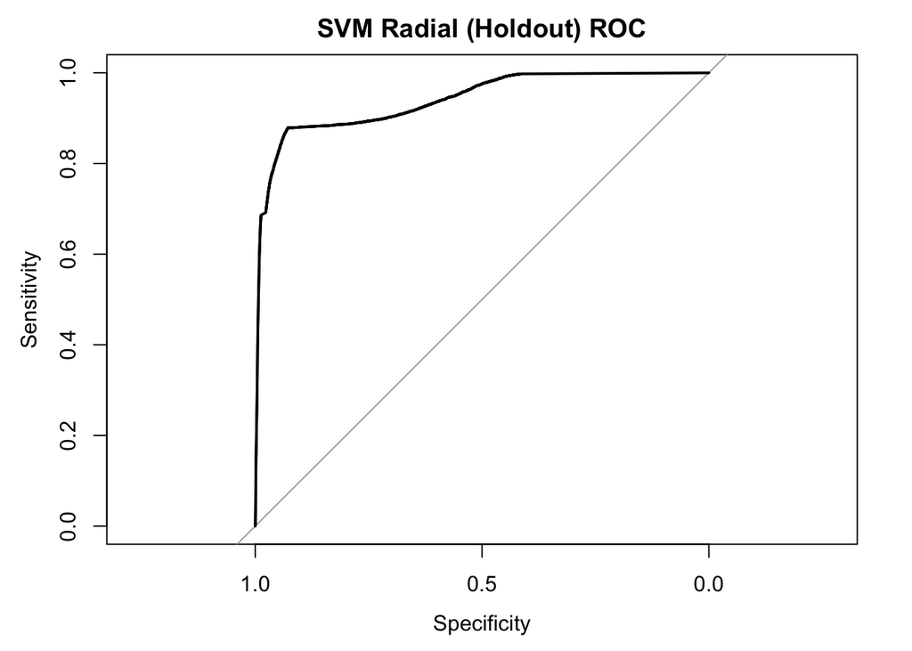

```r
# Grab the predictions of the Support Vector Machines model
svm.radial.hold.predict <- predict(svm.radial.model, holdout, probability=TRUE)
svm.radial.hold.probs <- attr(svm.radial.hold.predict, 'probabilities')[,2]
svm.radial.hold.preds <- rep(0,nrow(holdout)) # Create vector with all 0s
svm.radial.hold.preds[svm.radial.hold.probs > .25] = 1 # Replace zeros in above vector with 1 if above .5

# Grab the confusion matrix values for each fold
svm.radial.hold.tn <- table(svm.radial.hold.preds, blueTarpsHold)[1] # Grab all the True Negatives
svm.radial.hold.fp <- table(svm.radial.hold.preds, blueTarpsHold)[2] # Grab all the False Positives
svm.radial.hold.fn <- table(svm.radial.hold.preds, blueTarpsHold)[3] # Grab all the False Negatives
svm.radial.hold.tp <- table(svm.radial.hold.preds, blueTarpsHold)[4] # Grab all the True Positives

#AUC
svm.radial.hold.roc <- roc(blueTarpsHold, svm.radial.hold.probs, plot=TRUE, main= "SVM Radial (Holdout) ROC")
```

```r
svm.radial.hold.auc <- svm.radial.hold.roc$auc
svm.radial.hold.auc
```

```
## Area under the curve: 0.9401
```

```r
# Accuracy for each fold
svm.radial.hold.accuracy <- ((svm.radial.hold.tn + svm.radial.hold.tp)/(svm.radial.hold.tn + svm.radial.hold.tp + svm.radial.hold.fn + svm.radial.hold.fp))
svm.radial.hold.accuracy
```

```
## [1] 0.9873015
```

```r
# True Positive Rate for each fold
svm.radial.hold.tpr <-  (svm.radial.hold.tp / (svm.radial.hold.tp + svm.radial.hold.fn))
svm.radial.hold.tpr
```

```
## [1] 0.6277624
```

```r
# False Positive Rate for each fold
svm.radial.hold.fpr <- (svm.radial.hold.fp / (svm.radial.hold.fp + svm.radial.hold.tn))
svm.radial.hold.fpr
```

```
## [1] 0.01008194
```

```r
# Precision for each fold
svm.radial.hold.precision <- (svm.radial.hold.tp / (svm.radial.hold.tp + svm.radial.hold.fp))
svm.radial.hold.precision
```

```
## [1] 0.3118353
```

# Holdout Test Performance Table

```r
# Sources
# https://cran.r-project.org/web/packages/kableExtra/vignettes/awesome_table_in_html.html
# https://www.statology.org/create-table-in-r/

library(kableExtra) # Load library to create embedded table

# Create a data frame for required metrics
holdTable <- data.frame(Model=c("Logistic Regression", "LDA", "QDA", "KNN", "Penalized Log. Reg.", "Random Forest", "SVM - Radial"),Tuning =c("NA", "NA", "NA", 10, round(optimal.lambda,4), round(sqrt(3),4), "Cost - 100; Gamma - 4"), AUROC = c(log.hold.auc, lda.hold.auc, qda.hold.auc, knn.hold.auc, ridge.hold.auc, rf.hold.auc, svm.radial.hold.auc), Threshold = c(.14,.09,.1,.59,.01,.45, .25), Accuracy = c(log.hold.accuracy, lda.hold.accuracy, qda.hold.accuracy, knn.hold.accuracy, ridge.hold.accuracy,rf.hold.accuracy, svm.radial.hold.accuracy), TPR = c(log.hold.tpr, lda.hold.tpr, qda.hold.tpr, knn.hold.tpr, ridge.hold.tpr, rf.hold.tpr, svm.radial.hold.tpr), FPR = c(log.hold.fpr, lda.hold.fpr, qda.hold.fpr, knn.hold.fpr, ridge.hold.fpr, rf.hold.fpr, svm.radial.hold.fpr), Precision = c(log.hold.precision, lda.hold.precision, qda.hold.precision, knn.hold.precision, ridge.hold.precision, rf.hold.precision, svm.radial.hold.precision))

holdTable # See the data frame created
```

```
##                 Model                Tuning     AUROC Threshold  Accuracy
## 1 Logistic Regression                    NA 0.9994039      0.14 0.9394410
## 2                 LDA                    NA 0.9921096      0.09 0.9777789
## 3                 QDA                    NA 0.9915749      0.10 0.9813599
## 4                 KNN                    10 0.9536438      0.59 0.9927142
## 5 Penalized Log. Reg.                0.0042 0.9878890      0.01 0.5505941
## 6       Random Forest                1.7321 0.9818365      0.45 0.9926349
## 7        SVM - Radial Cost - 100; Gamma - 4 0.9400853      0.25 0.9873015
##         TPR         FPR  Precision
## 1 0.9991713 0.060993709 0.10651785
## 2 0.9080110 0.021713356 0.23332328
## 3 0.8247928 0.017500655 0.25538876
## 4 0.8127762 0.005976287 0.49742181
## 5 1.0000000 0.452676463 0.01582221
## 6 0.7907459 0.005895873 0.49393900
## 7 0.6277624 0.010081937 0.31183533
```

```r
# Creates embedded table into R Studio
holdTable %>%
  kbl(digits = 4) %>%
  kable_material_dark()
```

| Model | Tuning | AUROC | Threshold | Accuracy | TPR | FPR | Precision |
| --- | --- | --- | --- | --- | --- | --- | --- |
| Logistic Regression | NA | 0.9994 | 0.14 | 0.9394 | 0.9992 | 0.0610 | 0.1065 |
| LDA | NA | 0.9921 | 0.09 | 0.9778 | 0.9080 | 0.0217 | 0.2333 |
| QDA | NA | 0.9916 | 0.10 | 0.9814 | 0.8248 | 0.0175 | 0.2554 |
| KNN | 10 | 0.9536 | 0.59 | 0.9927 | 0.8128 | 0.0060 | 0.4974 |
| Penalized Log. Reg. | 0.0042 | 0.9879 | 0.01 | 0.5506 | 1.0000 | 0.4527 | 0.0158 |
| Random Forest | 1.7321 | 0.9818 | 0.45 | 0.9926 | 0.7907 | 0.0059 | 0.4939 |
| SVM - Radial | Cost - 100; Gamma - 4 | 0.9401 | 0.25 | 0.9873 | 0.6278 | 0.0101 | 0.3118 |

# Conclusions

## Conclusion 1

For the cross-validation data, the best performing algorithms were KNN, Random Forest, and SVM - Radial. From the AUC and Accuracy values, we get values of over 99% for each of these 3 models. For all metrics, we see consistently strong scores and, comparatively, the 3 models have similar scores for each metric (for the most part). Another characteristic of these 3 models is that their precision metric is substantially better (over 95%) than any of the remaining models (the next best model related to precision is logistic regression at 81%). A benefit of these 3 models is that methods were deployed to find the optimal tuning parameter values to get us the best results for each of these models - these results seem to indicate that we chose optimal values for these tuning parameters. Between these 3 models,they also all score over a 90% for TPR (KNN and Random Forest score over 95%) and FPRs less than 1%. This tells us that these models were very good at predicting correctly the observations that are blue tarps in the cross-validation data. Another thing to note is that logistic regression also seems to perform relatively well though has a significantly lower precision score than KNN, Random Forest, and SVM - Radial.

For our cross-validation data, it was relatively simple to identify the best performing algorithms because they consistently performed well on each metric and compared to other models. For the holdout data, determining the best performing algorithms was a bit trickier because the models performed well for some metrics and performed poorly in other metrics (note that all the models performed poorly in terms of precision which causes problems when having to consider our resource allocation constraint). If we did not have to consider resource constraints, we might want to go with either either logistic regression or ridge regression solely for the fact that they do incredibly well on their TPR (they identify most, if not all, the observations that are blue tarps). We might also consider LDA because the TPR rate is over 90%. Unfortunately, in a real-world scenario, resource constraints, like financial and labor assets, are limited. Keeping this balance in mind, KNN or Random Forest may be better suited for our objectives because, even though they have lower TPR rates, the TPR rates are still relatively high (~80%) and these models perform much better in regards to their FPR (less than 1%) and precision (~50%). If our scenario had some resources that they could expend, there could be a possibility of exploring logistic regression or LDA. We probably would not want to consider ridge regression because, although it has a 100% TPR, it performs significantly poorly on the other metrics. Overall, keeping in mind resource constraints, KNN and Random Forest are the best models based off their performance on the holdout data and given our limitations on what we could do in a real-world situation.

## Conclusion 2

Based on the analysis stated in Conclusion 1, we see that the best performing algorithms (keeping in mind resource constraints) concluded with the same results (with some caveats). From our analysis, KNN and Random Forest perform extremely well on the cross-validation data and performed well enough on the holdout data. We saw that SVM - Radial performed well on the cross-validation set but performed significantly poorer when looking at TPR and Precision. We also saw that logistic regression performed pretty well on both the cross-validation and holdout data sets - the problem with logistic regression is that its precision score on both data sets were lower than other models. This indicates that the model predicts more observations as blue tarps when they are not. This would be fine if we did not have to keep in mind the resource constraint identified in the introduction of this project. The logistic regression would be a great model to use if we had the ability to use as many resources as possible but we know that in a real-world scenario that there are restrictions to this.

I think that the consistent results between the cross-validation performance table and the holdout performance table can be seen in the fact that the cross-validation process was effective in detailing the performance of the models albeit on a lower number of observations. From the cross-validation process, we were able to see, at a high-level, which models were effective on the data set and then use the holdout set to verify this and scale down the metrics to see the models true effectiveness. Additionally, since we use the same thresholds and tuning parameters from the cross-validation set, this seems to ensure that we will get similar results (not necessarily on metric values but how well each model performed compared to other models).

It is also important to note that even though the best performing models between the cross-validation and holdout data are similar, the metrics calculated were not similar. We saw that, for many metrics, the performance of some of the models went significantly down. For example, many of the models had TPR rates in the high 90s while, in the holdout data, that has dipped. We also see that the major difference between the two tables is that the precision of each model have performed terribly. We can understand that this difference comes mainly from the number of observations that were used to test and train in the cross-validation process compared to the holdout data set (see Conclusion 6 for further discussion).

## Conclusion 3

My recommendation for the algorithm to use to detect blue tarps is the KNN model. We saw from the cross-validation data set that KNN had very high performance on each metric and was able to identify 95% of the observations that were blue tarps while avoiding predicting too many observations as blue tarps when they were not blue tarps. The main reason, though, that KNN was selected as the optimal model was based on what we saw from the holdout data set. The KNN model performed fairly well but not as well as some of the other models like logistic regression and LDA when it came to TPR. Unfortunately, we see that both of these models suffer from very low precision rates at the expense of these high TPR values and have an FPR rate that is higher (KNN FPR is less than 1%). Also, since we need to identify blue tarps within a resource constraint, the low values for precision seen from Logistic Regression and LDA on the holdout data set showed that using these models would lead to using resources incorrectly and identifying observations that are not actually blue tarps. Looking at the KNN model, though, we see that it has the highest precision score and has a TPR of ~81%, which isn’t the highest of all the models but overall still a pretty solid score when considering an assumed resource constraint. Because of these assumptions and constraints, I believe KNN is the best model to meet our objectives.

If we didn’t worry about resources at all, I would most likely recommend the logistic regression model because it is able to identify almost all the observations that are blue tarps. This would undoubtedly lead us to incorrectly identify other observations as blue tarps when they are not but we would still predict correctly the blue tarps that are blue tarps. A scenario where resources are unlimited or not a factor would undoubtedly require me to go with the logistic regression.

Some people, when looking at the results, may have selected Random Forest as the appropriate choice because it performed similarly to KNN in the cross-validation and holdout data sets. My rationale for selecting KNN over Random Forest was the fact that, in the holdout data set, we see that KNN performs slightly better in TPR and Precision which were the two metrics that I was most concerned about. Random Forest does have a higher AUC score but not enough to warrant selecting it over KNN.

## Conclusion 4

In the context of this project, we saw that the values gathered from each model’s confusion matrix (which contain the TP, FP, TN, and FN) were able to calculate the various metric that were consolidated into the performance tables. The basis of this analysis was to identify the model that would correctly observe the most blue tarps while also keeping in mind the real-world context of this project. The metrics that I was closely observing were the TPR, Precision, and FPR because these values seemed to be the metrics that varied and were impactful to our objective. The TPR was useful in detailing how many of the observations that were blue tarps were correctly identified as blue tarps. This metric helped to answer the m main question of how many blue tarps were correctly identified. As mentioned previously, a resource constraint was considered in these conclusions and final analysis.

The FPR and Precision metrics were helpful in explaining how off these models predictions were in context and helping to account for how badly resources could potentially be wasted. We know that in a real-world situation that we want to be timely in finding these blue tarps which means that our models need to be effective at predicting what is and is not a blue tarp so the resources can be used on the blue tarp observations. We wanted to avoid resources being used on something that was predicted as a blue tarp but was in reality not a blue tarp (or miss an observation that was a blue tarp but was predicted as something else). The FPR helped to describe how badly our model predicted an observation as a blue tarp when it was not (i.e. sending resources to a location that did not have blue tarps) which is something we wanted to minimize. The KNN model had less than a 1% rate for FPR which was a reason I selected it as the best model for our objectives. The precision also detailed how well the model was able to identify blue tarps out of all the possible blue tarp observations.

The AUC value helped to show how well our model classified the observations and all the models did pretty well in this aspect (which can be seen in how well the ROC curves hug the top left corner of the plot). The accuracy of each model described how well the model correctly classified an observation (whether it was or was not a blue tarp) out of all the observations. A low accuracy identified a model that would incorrectly predict an observation in general - for the most part, all the models faired well in this aspect except the ridge regression model.

The threshold metric was important in order to calibrate our model to identify the most blue tarps correctly as possible. As described in the Threshold Selection section, the thresholds of each model were determined based on how much additional improvement that a change in the threshold would give (in this case, how much would a lower threshold be beneficial to improve the model prediction). We wanted to reduce the threshold because this would reduce the number of false negatives (i.e. the observations that were predicted as not a blue tarp but were) but in a way that there was a substantially improvement in the TPR. In our situation, this was important because we wanted to reduce the chance that we would pass over an observation that was a blue tarp but we classified as not a blue tarp. We also had to keep in mind that reducing the threshold increased the likelihood of an increase in false positives. This is why in the Threshold Justification section we only placed the threshold value to something that actually showed substantial improvement (i.e. assumed every 5% was a “substantial improvement”). For the tuning parameter, the methods used to identify the tuning parameter helped to develop the optimal model for KNN, Ridge Regression, Random Forest, and SVM. Cross-validation was useful in helping to determine some of these tuning parameters.

## Conclusion 5

For future analysis into this project, I think that more information on the resources available would be useful as a tool to better determine the model that is most suitable for this problem statement. From the problem statement, it was understood that we wanted to identify as many blue tarps as possible in a timely manner which meant we didn’t want to use our resources loosely. This is how models like logistic regression were not selected as the most optimal model for this problem because, even though they were effective at identifying what was a blue tarp, it did this at the expense of identifying other observations falsely. A look into the labor provided and the finances given to this rescue effort would give us the kind of context needed to determine, more accurately, the optimal model. This also goes back to the selection of the thresholds - they were determined based on an assumption in regards to the marginal benefit of decreasing the threshold at the expense of using resources on a mis-predicted observation (i.e. was there enough marginal benefit to justify decreasing the threshold). We would better be able to determine a tuning parameter if we knew how restrictive (or flexible) the resource constraints were. It is understood that in a real-world scenario that the the best performing model selected is exactly because we do not have the resources to check every location and therefore need to determine a model that will predict the most blue tarps correctly with minimal resource expenditure/wastefulness.

Additionally, when looking at the holdout data, the main thing stopping me from saying that these models would be useful in a real-world scenario are the very low precision values (at least compared to what we saw in cross-validation). This leads me to believe that implementation of any of these models would lead to some level of wastefulness of resources to examine locations that don’t have blue tarps or miss areas that do have blue tarps. In a real-world scenario, we see that KNN is probably the most effective model keeping in mind the constraints that we had. In a perfect world, logistic regression would probably be the best to use because it performs so well in most metrics except precision. This would be something I’d like to look further into - why these models seemed to perform so well, in terms of precision, on the cross-validation and then had a significant drop in the holdout data set. I would want to do some further analysis into methods that may help us resolve the low precision values (without too much drop in the other metrics).

Another thing that I would want to look further into is into the results of our ridge regression model. From my analysis, I was able to manipulate the threshold value to get us perfect TPR but using another threshold value (in Part 1 analysis), I was able to get 0% FPR and 100% precision. Changes in the threshold value of the ridge regression model seemed to have the highest impact on determining the results. It also seemed that, in the other metrics, that ridge regression performed the worst out of all the models (even with 100% TPR). I would be interested in understanding if there are workarounds to improve the performance of ridge regression while maintaining its high TPR. Also, I think that looking into lasso regression and seeing if that provided any improvement would be interesting too.

## Conclusion 6

My analysis of these models on the data set also further demonstrated how impactful more observations in an analysis are to get accurate results. Between the cross-validation and holdout data, we saw substantially deviations between the two performance tables on many metrics. From our cross-validation process in Part 1, we dealt with over 60,000 observations where only a tenth of that data was used as test data at a time. From these results, though, we saw that a lot of our models performed strongly and that there were were clear winners in terms of the best performing algorithm. On top of that, using cross-validation, we were not able to use the full training data because a tenth of it had to be used as test data each round and averaged between the 10 folds.

In Part 2, we dealt with a test data set of over 2 million observations, compared to only using a little over 6000 in each fold during cross-validation, and saw how that significantly changed the performance of each model. As mentioned earlier, it was difficult to determine a clear winner from the holdout data set because of the fluctuations in metrics while the cross-validation results were consistent. I think that, performance wise, we were able to see which models specifically would perform well but understanding the metrics and how impactful these models would be were severely inflated in the cross-validation performance table. If we had used the holdout data set as our cross-validation set and vice versa, we probably would have seen similar results between the two performance tables.

In reality, we may face situations in which we have to deal with a limited data set and make our predictions based on these with the caveat that we are only dealing with a limited number of observations. We have to be careful in our approach with this type of data set - it could have been very easy to look at the cross-validation results and proceed with one of the models based off that. This could have bad ramifications if incorporated because the models had not been tested against a lot of observations.